# Student math scores

#### Data background:

Ms. Ruger, Ms. Smith and Ms. Wesson are the new superintendents of a Junior High School that consists of approximately 500 students in grades 7-8.  
Students are randomly assigned to grade-level, subject-specific classroom teachers. The ethnic composition of the school is relatively diverse consisting primarily of African-American, Hispanic, Asian, and Caucasian students.  
Each teacher was allowed to use their preferred teaching method and to select their own textbook three years ago. Ms. Wesson proposes that all three teachers should be using the standards-based approach to teaching.Ms. Smith disagrees and shares an article that she has read that states that students in traditional programs may have better procedural skills, but definitely lack in problem-solving creativity. The next day you receive a call from the school board president regarding the two teaching methods used by the teachers. The president wants you to present your recommendation at the board meeting for a specific teaching method – standards-based or traditional – based on your analysis of the 8th grade test scores.

##### Questions:

- Should students be separated by ethnicity?
- Which teaching method is the best?
- Should all three teachers use the same teaching style?

#### Data Exploration:

```r
library(tidyverse)
library(haven)
library(ggplot2)
library(ggsci) # graph colors
library(ggthemes)
library(patchwork)
```

```r
#Import the data and check it's values
math_scores <- read_sav("1ResearchProjectData.sav")

lapply(math_scores, unique)
```

```
## $Student
##   [1]   1   2   3   4   5   6   7   8   9  10  11  12  13  14  15  16  17  18
##  [19]  19  20  21  22  23  24  25  26  27  28  29  30  31  32  33  34  35  36
##  [37]  37  38  39  40  41  42  43  44  45  46  47  48  49  50  51  52  53  54
##  [55]  55  56  57  58  59  60  61  62  63  64  65  66  67  68  69  70  71  72
##  [73]  73  74  75  76  77  78  79  80  81  82  83  84  85  86  87  88  89  90
##  [91]  91  92  93  94  95  96  97  98  99 100 101 102 103 104 105 106 107 108
## [109] 109 110 111 112 113 114 115 116 117 118 119 120 121 122 123 124 125 126
## [127] 127 128 129 130 131 132 133 134 135 136 137 138 139 140 141 142 143 144
## [145] 145 146 147 148 149 150 151 152 153 154 155 156 157 158 159 160 161 162
## [163] 163 164 165 166 167 168 169 170 171 172 173 174 175 176 177 178 179 180
## [181] 181 182 183 184 185 186 187 188 189 190 191 192 193 194 195 196 197 198
## [199] 199 200 201 202 203 204 205 206 207 208 209 210 211 212 213 214 215 216
## [217]  NA
##
## $Teacher
## <labelled<double>[4]>
## [1]  1  2  3 NA
##
## Labels:
##  value  label
##      1  Ruger
##      2  Smith
##      3 Wesson
##
## $Gender
## <labelled<double>[3]>
## [1]  1  2 NA
##
## Labels:
##  value  label
##      1 Female
##      2   Male
##
## $Ethnic
## <labelled<double>[5]>
## [1]  1  3  2  4 NA
##
## Labels:
##  value            label
```

[output cut: 12 more lines]

```
##      2 Paid lunch
##
## $Score
##  [1] 76 56 34 59 73 58 62 40 82 78 64 68 39 48 66 72 60 54 30 43 44 67 37 32 42
## [26] 33 47 65 36 50 74 75 69 52 80 51 71 57 77 38 55 85 45 49 89 91 79 87 46 95
## [51] 53 83 92 61 84 86 93 70 88 63 81 90 94 NA
##
## $wesson
## <labelled<double>[2]>
## [1] 0 1
##
## Labels:
##  value       label
##      0 Ruger_Smith
##      1      Wesson
```

```r
#convert from <dbl+lbl> format of the .sav file to factors
math_scores_f <- as_factor(math_scores)
```

```r
# check the summary of the data
summary(math_scores_f)
```

```
##     Student         Teacher      Gender                 Ethnic
##  Min.   :  1.00   Ruger :71   Female: 96   Asian           :53
##  1st Qu.: 54.75   Smith :69   Male  :120   African-American:52
##  Median :108.50   Wesson:76   NA's  :  1   Hispanic        :66
##  Mean   :108.50   NA's  : 1                Caucasian       :45
##  3rd Qu.:162.25                            NA's            : 1
##  Max.   :216.00
##  NA's   :1
##        Freeredu       Score               wesson
##  Free lunch:104   Min.   :30.00   Ruger_Smith:141
##  Paid lunch:112   1st Qu.:53.00   Wesson     : 76
##  NA's      :  1   Median :65.00
##                   Mean   :65.27
##                   3rd Qu.:79.00
##                   Max.   :95.00
##                   NA's   :1
```

```r
#rename wesson column and the data under it to better reflect the data about teaching style
math_scores_f <- math_scores_f %>% rename(style = wesson) %>% mutate(style = case_when(
  style == "Ruger_Smith" ~ "standard",
  style == "Wesson" ~ "traditional"
))
```

```r
# explore the null data. It looks like it has a label value just not the numerical one.
#looking at the View, it looks like it is a duplicate of row 6. So I remove it
math_scores_f[rowSums(is.na(math_scores_f)),]
```

```
## # A tibble: 1 x 7
##   Student Teacher Gender Ethnic    Freeredu   Score style
##     <dbl> <fct>   <fct>  <fct>     <fct>      <dbl> <chr>
## 1       6 Ruger   Male   Caucasian Paid lunch    58 standard
```

```r
math_scores_f <- math_scores_f[-c(217),]
math_scores_f <- math_scores_f %>% select("Teacher", "Gender", "Ethnic", "Freeredu", "Score", "style")
```

After going over the summary data again, none of the professors are flawless. The overall average score for all students is roughly 65. None of the pupils received a perfect score, and the lowest was a 30.

```r
summary(math_scores_f)
```

```
##    Teacher      Gender                 Ethnic         Freeredu
##  Ruger :71   Female: 96   Asian           :53   Free lunch:104
##  Smith :69   Male  :120   African-American:52   Paid lunch:112
##  Wesson:76                Hispanic        :66
##                           Caucasian       :45
##
##
##      Score          style
##  Min.   :30.00   Length:216
##  1st Qu.:53.00   Class :character
##  Median :65.00   Mode  :character
##  Mean   :65.27
##  3rd Qu.:79.00
##  Max.   :95.00
```

The total number of students is spread out pretty evenly between the teachers. So even though Mr. Smith has seven fewer students than Ms. Wesson, it’s not so much as to be overwhelming.

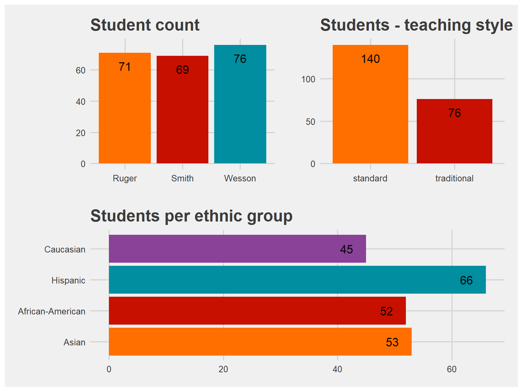

```r
#check how many students each teacher has
a <- math_scores_f %>% group_by(Teacher) %>% count(Teacher) %>% ggplot(aes(Teacher, n, fill = Teacher)) +
  geom_col(show.legend = FALSE) + theme_fivethirtyeight() + labs(title = "Student count") +
  geom_text(aes(label = n, vjust = 2, size = 5), show.legend = FALSE) + scale_fill_futurama()

b <- math_scores_f %>% group_by(style) %>% count(style) %>% ggplot(aes(style, n, fill = style)) +
  geom_col(show.legend = FALSE) + theme_fivethirtyeight() + labs(title = "Students - teaching style") +
  geom_text(aes(label = n, vjust = 2, size = 5), show.legend = FALSE) + scale_fill_futurama()

c <- math_scores_f %>% group_by(Ethnic) %>% count(Ethnic) %>% ggplot(aes(Ethnic, n, fill = Ethnic)) +
  geom_col(show.legend = FALSE) + theme_fivethirtyeight() + labs(title = "Students per ethnic group") +
  geom_text(aes(label = n, hjust = 2, size = 5), show.legend = FALSE) + scale_fill_futurama() + coord_flip()

(a+b)/c
```

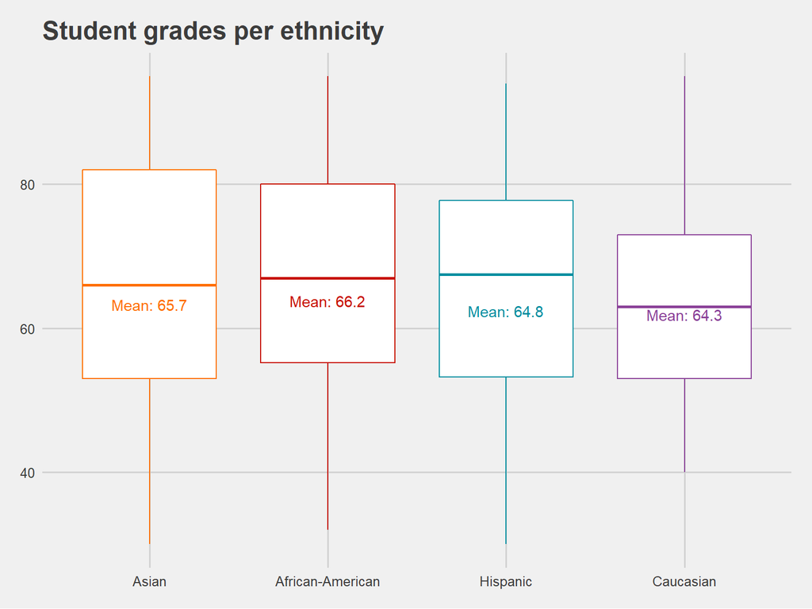

```r
#check the scores based on ethnicity
math_scores_f %>% ggplot(aes(Ethnic, Score, color = Ethnic)) + geom_boxplot(show.legend = FALSE) +
  theme_fivethirtyeight() + scale_color_futurama() + guides(color = "none", size = "none") +
  labs(title = "Student grades per ethnicity") + stat_summary(fun = mean, geom = "text",
                                                              vjust = 2, aes(label = paste("Mean:", round(..y.., digits = 1))))
```

The traditional teaching style has a higher average score; however, it has half the students.

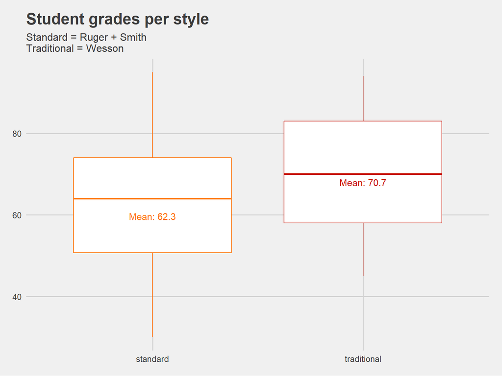

```r
# check average based on teaching style
math_scores_f %>% ggplot(aes(style, Score, color = style)) + geom_boxplot(show.legend = FALSE) +
  theme_fivethirtyeight() + scale_color_futurama() + guides(color = "none", size = "none") +
  labs(title = "Student grades per style", subtitle = "Standard = Ruger + Smith \nTraditional = Wesson") + stat_summary(fun = mean, geom = "text",
               vjust = 2, aes(label = paste("Mean:", round(..y.., digits = 1))))
```

After looking at the scores based on the teacher, it’s evident that Mr. Ruger’s students are behind the students of the other teachers. Average, max, and min scores are lower, with the average score almost 15 points lower. So far, among all the data, this is the clearest.

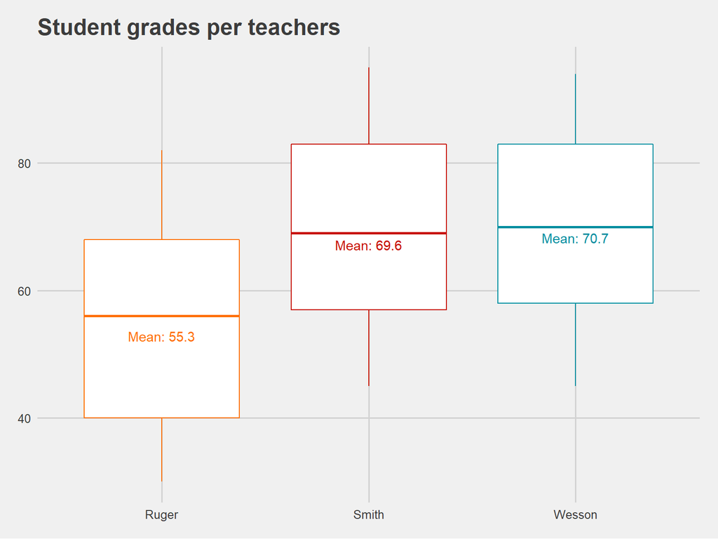

```r
#check the average score per teacher
math_scores_f %>% ggplot(aes(Teacher, Score, color = Teacher)) + geom_boxplot(show.legend = FALSE) +
  theme_fivethirtyeight() + scale_color_futurama() + guides(color = "none", size = "none") +
  labs(title = "Student grades per teachers") + stat_summary(fun = mean, geom = "text",
                                                          vjust = 2, aes(label = paste("Mean:", round(..y.., digits = 1))))
```

Now I want to see what had the largest impact on the student scores. I will try to do this using the random forest.

```r
#random forest to predict which variable had the biggest impact
library(caret)
library(randomForest)
```

```r
set.seed(719) # set a random seed

data_size <- floor(nrow(math_scores_f)) #get data size
data_index <- sample(1:nrow(math_scores_f), size = data_size) #randomize the data
data_training <- math_scores_f[data_index,] # put the randomized data into a new data frame
```

```r
rf <- randomForest(Score ~., data = data_training, mtry=1, ntree = 2001) # train data
imp <- varImpPlot(rf) # put the results into a new data frame
```

Looking at the graph, the teacher is most important, followed by style.

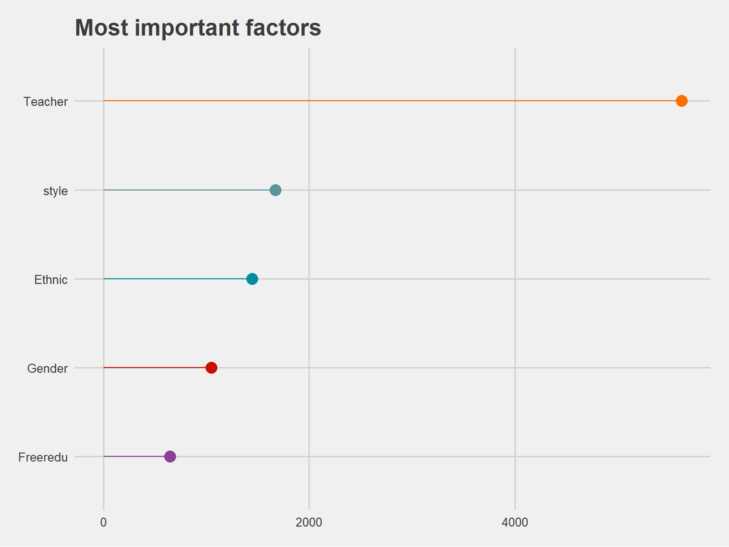

```r
#plot it
imp <- as.data.frame(imp)
imp$varnames <- rownames(imp) # row names to column
rownames(imp) <- NULL
imp$var_categ <- rep(1:5) # random var category

ggplot(imp, aes(x=reorder(varnames, IncNodePurity), y=IncNodePurity, color=as.factor(var_categ))) +
  geom_point(size = 4, show.legend = FALSE) +
  geom_segment(aes(x=varnames,xend=varnames,y=0,yend=IncNodePurity), show.legend = FALSE) +
  scale_color_discrete(name="Variable Group") +
  theme_fivethirtyeight() + scale_color_futurama() +
  coord_flip() + labs(title = "Most important factors")
```

#### Conclusion:

##### Should students be separated by ethnicity?

Students should not be separated based on ethnicity. No one ethnicity is doing better than the other. Separating them can cause more harm than good.

##### Which teaching method is the best?

The traditional teaching method results in higher overall scores

##### Should all three teachers use the same teaching style?

Although Smith’s standard teaching approach produces a good math score, even though it is somewhat lower than using Wesson’s traditional teaching method, it is not acceptable to conclude that the traditional method is superior.

According to the findings, the teacher is the most critical element in a student’s math score. The school should address the problem of teaching competency. Perhaps certain teachers are difficult for the children to comprehend. First and foremost, the school should give training and a way for teachers to improve their skills.